# ETC 1010 Assignment 2

5T

```r
library(tidyverse)
library(ggplot2)
survey <- read_csv("data/survey.csv",
                    na = c("n/a", "NA")) %>%
  filter(id != 64)
#tidysurvey <- read_csv("~/Documents/Uni/ETC1010/Assignment 2/survey_tidy.csv")
```

# Recode Q1 to have answers 1,2,3,4, Other

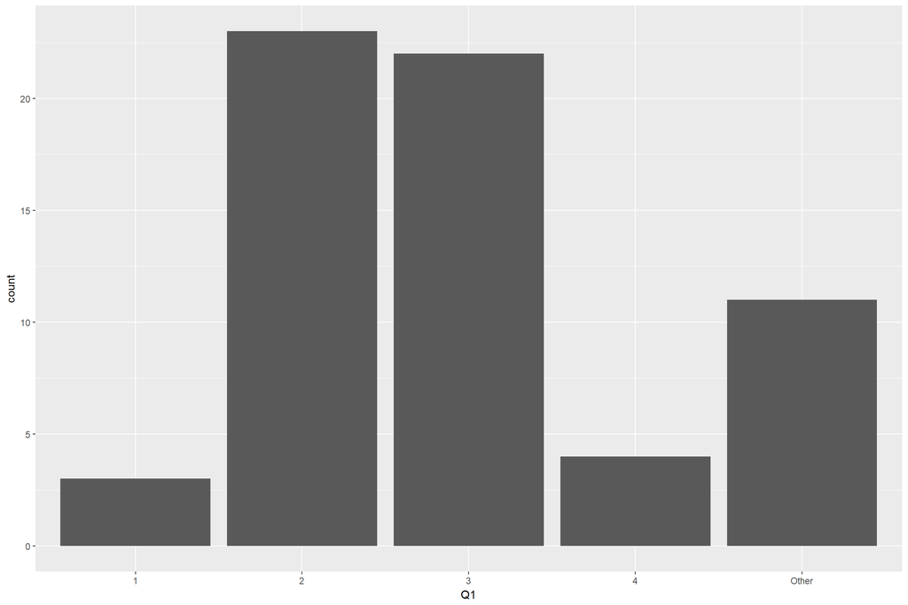

```r
library(dplyr)
survey$Q1[survey$Q1=="A"] <- 1
survey$Q1[survey$Q1=="B"] <- 2
survey$Q1[survey$Q1=="C"] <- 3
survey$Q1[survey$Q1=="D"] <- 4
survey$Q1[survey$Q1=="E"] <- "Other"
ggplot(data = survey, aes(x=Q1)) +
  geom_bar()
```

The majority of the class are in second year, wth third years closely following. Interestingly, first years are the minority even though this is a first year unit. This could be because ETC1000 is a prerequisite, so many first years will be ineligible to take this unit in this semester.

# Cleaning up Q2

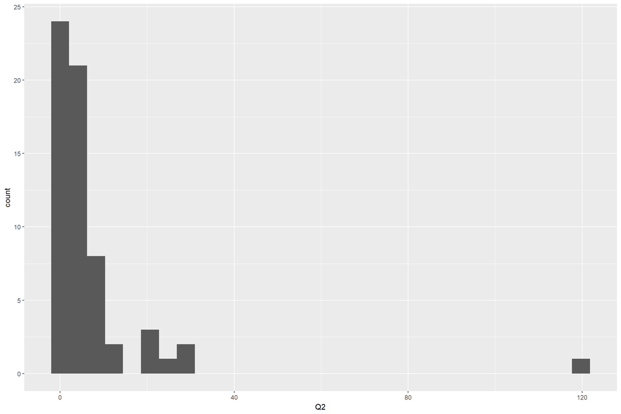

```r
library(stringr)
survey <- survey %>%
  #change 1/2 to 0.5
  mutate(Q2 = sub("1/2", "0.5", Q2)) %>%
  #remove hours
  mutate(Q2 = sub(" hours", "", Q2)) %>%
  #remobe \n
  mutate(Q2 = sub("\n", "", Q2)) %>%
  #remove hrs
  mutate(Q2 = sub("hrs", "", Q2)) %>%
  #remove HOUR
  mutate(Q2 = sub("HOUR", "", Q2)) %>%
  #change 4/7 to 0.57
  mutate(Q2 = sub("4/7", "0.57", Q2)) %>%
  #remove three times
  mutate(Q2 = sub("three times", "", Q2))
#this changes the value in Q2 on line 27 to "2.0"
survey$Q2[27] <- "2.0"
#this mutates all the values in Q2 to be numbers
survey <- survey %>% mutate(Q2 = as.numeric(Q2))
ggplot(survey, aes(x=Q2)) + geom_histogram()
```

The majority of students takes a short time to commute to uni with the highest being 120 hours.

Cleaning up Q3:

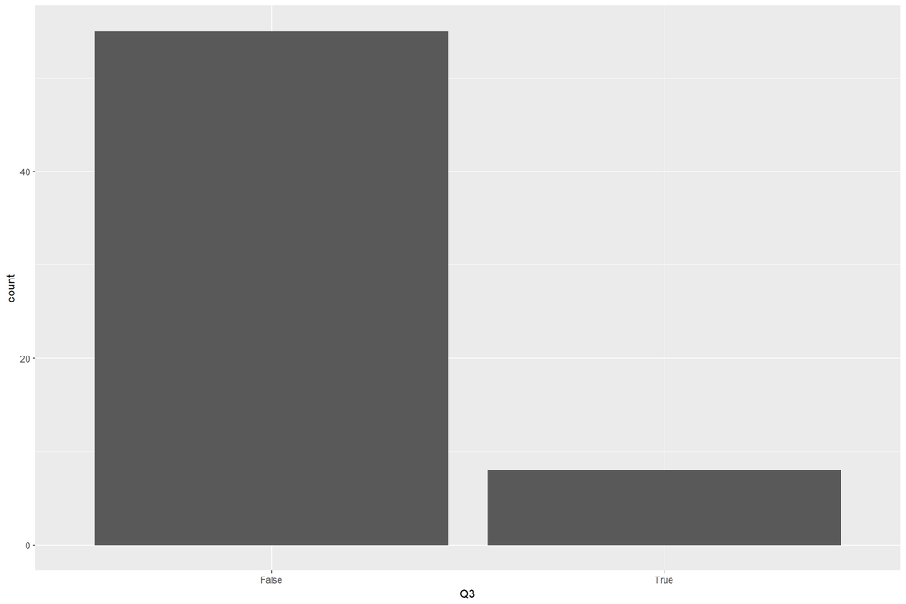

```r
ggplot(data = survey, aes(x=Q3)) +
  geom_bar()
```

The majority of the class did not attend Ed Sheeran’s concert.

Cleaning up Q4:

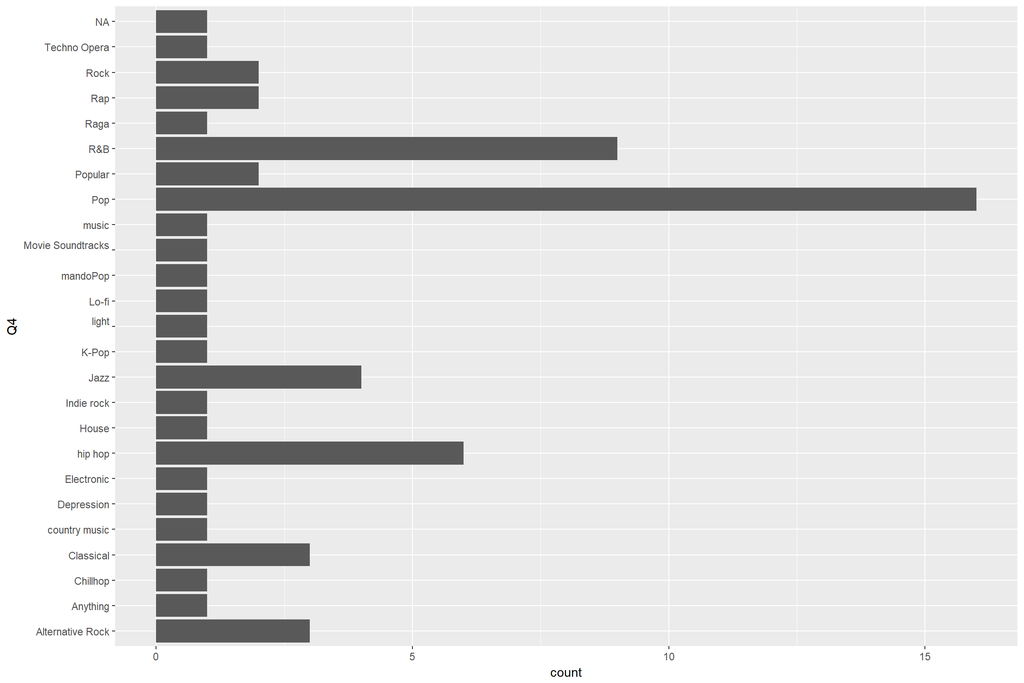

```r
survey <- survey %>%
  #changing alt rock to Alternative Rock
  mutate(Q4 = sub("alt rock", "Alternative Rock", Q4)) %>%
  #Changing classical to Classical
  mutate(Q4 = sub("classical", "Classical", Q4)) %>%
  #change hip hop variations to hip hop
  mutate(Q4 = sub("Hip hop", "hip hop", Q4)) %>%
  mutate(Q4 = sub("Hip Hop", "hip hop", Q4)) %>%
  mutate(Q4 = sub("hip-hop", "hip hop", Q4)) %>%
  mutate(Q4 = sub("hip-pop", "hip hop", Q4)) %>%
  mutate(Q4 = sub("Hiphop", "hip hop", Q4)) %>%
  mutate(Q4 = sub("hip Pop", "hip hop", Q4)) %>%
  #change jazz to Jazz
  mutate(Q4 = sub("jazz", "Jazz", Q4)) %>%
  #change pop music variation to Pop
  mutate(Q4 = sub("pop", "Pop", Q4)) %>%
  mutate(Q4 = sub("pop music", "Pop", Q4)) %>%
  mutate(Q4 = sub("Pop music", "Pop", Q4)) %>%
  #changing R&B variations to R&B
  mutate(Q4 = sub("rnb", "R&B", Q4)) %>%
  mutate(Q4 = sub("RnB", "R&B", Q4)) %>%
  mutate(Q4 = sub("RNB", "R&B", Q4)) %>%
  #changing Rock and/or Roll to Rock
  mutate(Q4 = sub("Rock and/or Roll", "Rock", Q4))
#change - to NA
survey$Q4[46] <- NA
ggplot(data = survey, aes(x=Q4, na.rm = TRUE)) +
  geom_bar() + coord_flip()
```

The top 3 most listened to genres of music are Pop, R&B and hip hop.

# Cleaning up Q5

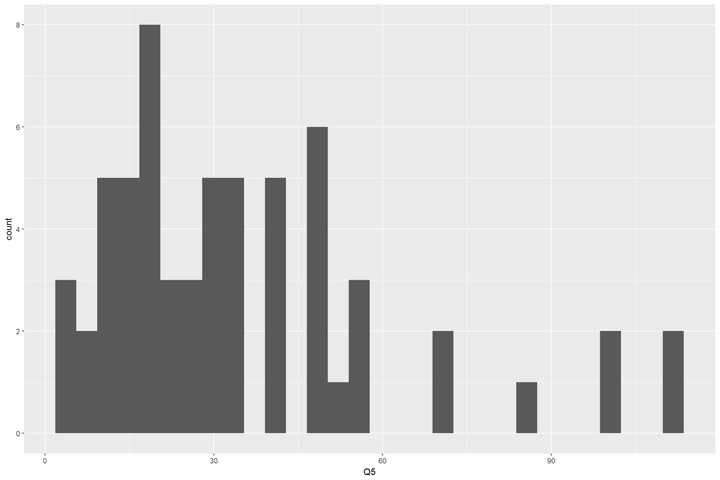

```r
library(tidyverse)
library(stringr)

survey <- survey %>%
  #"Choosing not to answer" turned into NA
  # remove "\n"
  mutate(Q5 = sub("\n", "", Q5)) %>%
  # remove "hrs"
  mutate(Q5 = sub("hrs", "", Q5)) %>%
  #remove Hours
  mutate(Q5 = sub("Hours", "", Q5)) %>%
    #remove hours
  mutate(Q5 = sub("hours", "", Q5)) %>%
    #remove HOUR
  mutate(Q5 = sub("HOUR", "", Q5))

survey$Q5[27] <- "40.0"

survey <- survey %>% mutate(Q5 = as.numeric(Q5))

ggplot(data=survey, aes(x=Q5)) +
  geom_histogram()
```

The majority of students spend around 0 to 30 hours on the internet each week.

# Cleaning up Q6:

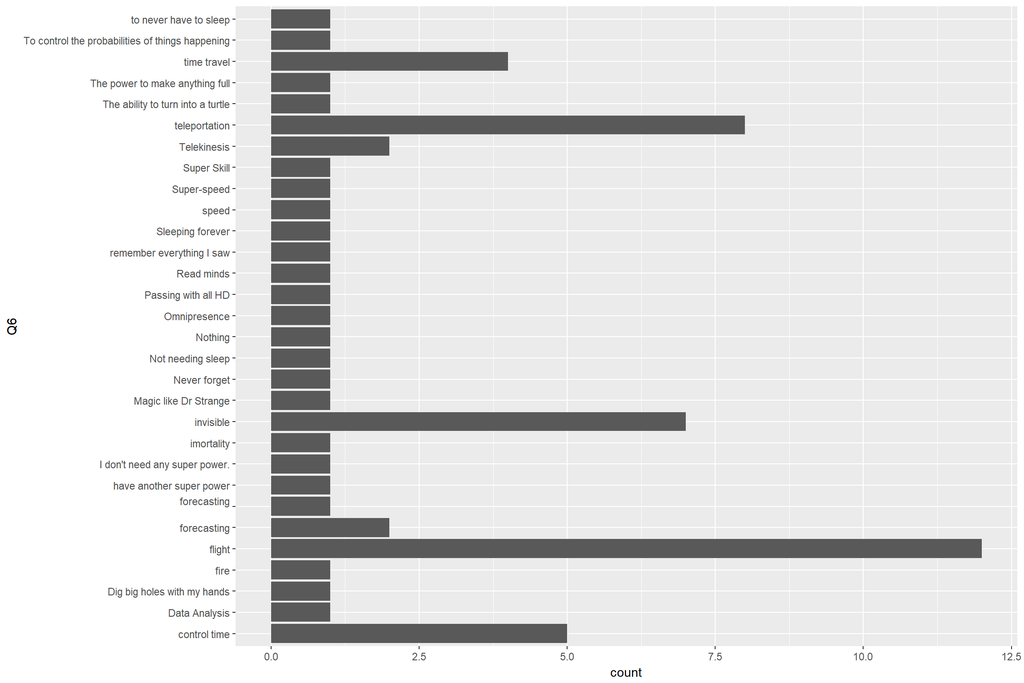

```r
survey <- survey %>%
  #cleaning up all the responses relating to flying to "flight"
  mutate(Q6 = sub("Flight", "flight", Q6)) %>%
  mutate(Q6 = sub("Flying", "flight", Q6)) %>%
  mutate(Q6 = sub("flying", "flight", Q6)) %>%
  mutate(Q6 = sub("fly", "flight", Q6)) %>%
  mutate(Q6 = sub("Fly", "flight", Q6)) %>%
  #cleaning up all the responses relationg to time travel to "time travel"
  mutate(Q6 = sub("Time travel", "time travel", Q6)) %>%
  mutate(Q6 = sub("go back to a past time", "time travel", Q6)) %>%
  mutate(Q6 = sub("can go to wherever i want in any time", "time travel", Q6)) %>%
  #cleaning up all the responses related to control time to "control time"
  mutate(Q6 = sub("Time-Reverse", "control time", Q6)) %>%
  mutate(Q6 = sub("freeze time", "control time", Q6)) %>%
  mutate(Q6 = sub("Control Time", "control time", Q6)) %>%
  mutate(Q6 = sub("time control", "control time", Q6)) %>%
  #cleaning up all the responses related to forecasting to "forecasting"
  mutate(Q6 = sub("predict the future", "forecasting", Q6)) %>%
  mutate(Q6 = sub("forecast the future", "forecasting", Q6)) %>%
  #cleaning up all the responses relating to insivibility to "invisible"
  mutate(Q6 = sub("Invisible", "invisible", Q6)) %>%
  mutate(Q6 = sub("Invisibility", "invisible", Q6)) %>%
  mutate(Q6 = sub("invisibility", "invisible", Q6)) %>%
  #cleaning up all the responses relating to teleporting to "teleportation"
  mutate(Q6 = sub("teleporting", "teleportation", Q6)) %>%
  mutate(Q6 = sub("Teleportation", "teleportation", Q6))
survey$Q6[survey$Q6=="time"] <- "control time"
ggplot(data = survey, aes(x=Q6, na.rm = TRUE)) +
  geom_bar() + coord_flip()
```

The top 3 most wanted super powers in the class are flight, invisibility and teleportation.

# Cleaning up Q7:

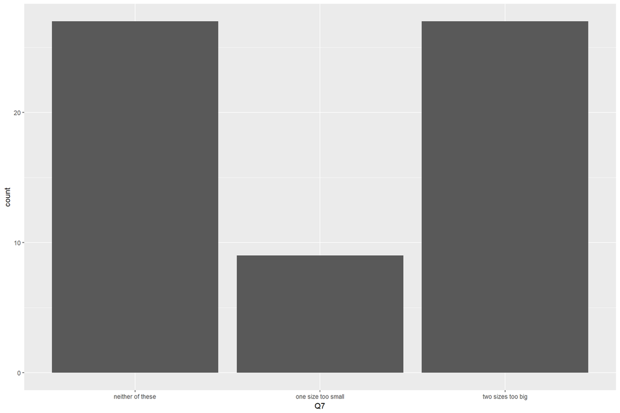

```r
#changing answer names
survey$Q7[survey$Q7=="A"] <- "two sizes too big"
survey$Q7[survey$Q7=="B"] <- "one size too small"
survey$Q7[survey$Q7=="C"] <- "neither of these"
ggplot(data = survey, aes(x = Q7)) +
  geom_bar()
```

The class prefers either clothes two sizes too big or clothes just right and this is split pretty evenly.

# Cleaning up Q8:

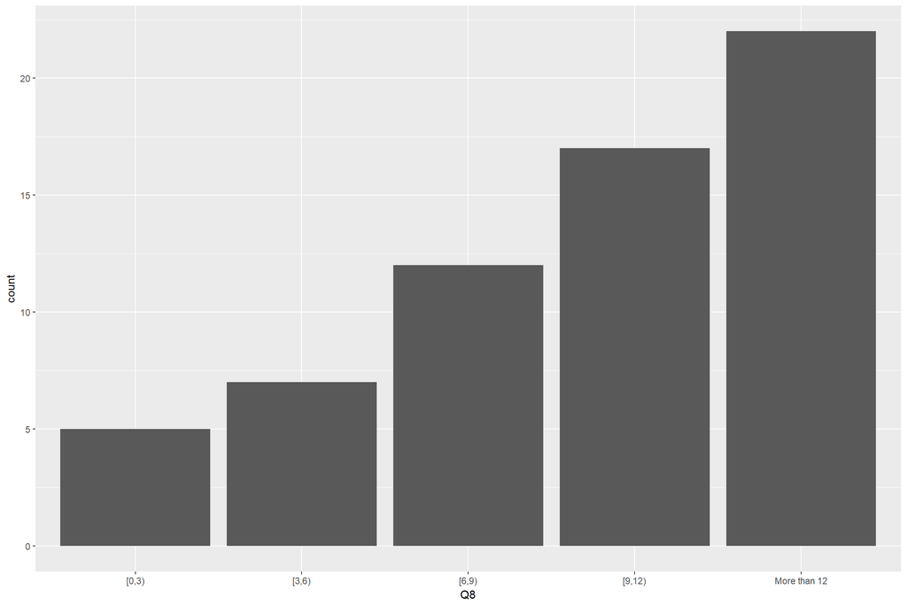

```r
#changing answer names
survey$Q8[survey$Q8=="A"] <- "[0,3)"
survey$Q8[survey$Q8=="B"] <- "[3,6)"
survey$Q8[survey$Q8=="C"] <- "[6,9)"
survey$Q8[survey$Q8=="D"] <- "[9,12)"
survey$Q8[survey$Q8=="E"] <- "More than 12"
ggplot(data = survey, aes(x = Q8)) +
  geom_bar()
```

# Cleaning up Q9:

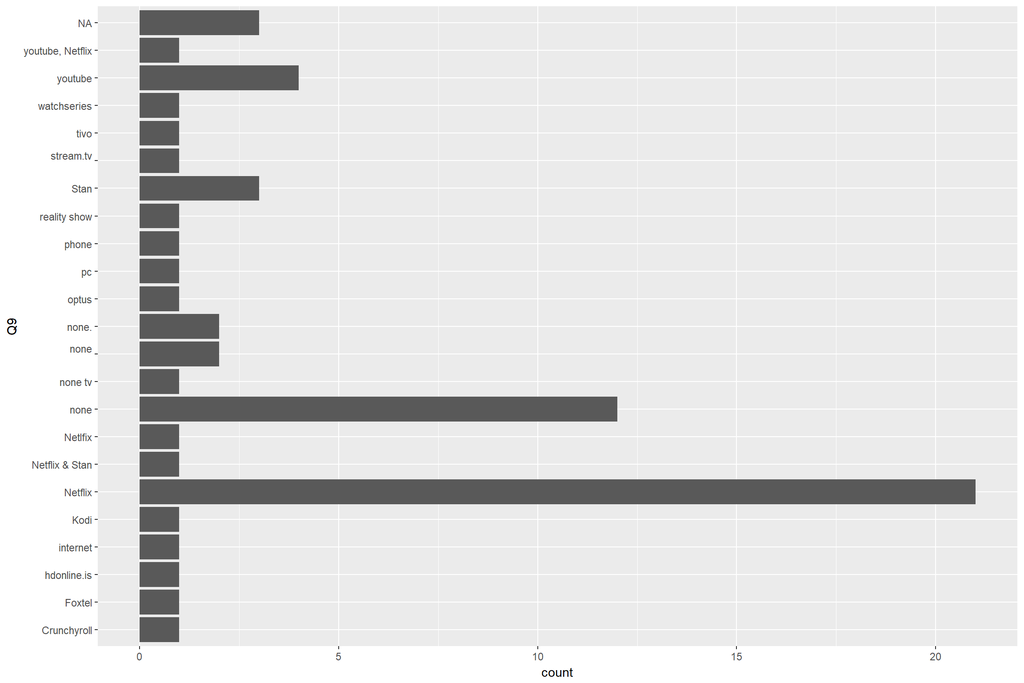

```r
#changing all the responses related to not watching television to "none"
survey <- survey %>%
  mutate(Q9 = sub("no idea", "none", Q9)) %>%
  mutate(Q9 = sub("None", "none", Q9)) %>%
  mutate(Q9 = sub("No television", "none", Q9)) %>%
  mutate(Q9 = sub("I do not watch television", "none", Q9)) %>%
  mutate(Q9 = sub("I don't watch television", "none", Q9)) %>%
  mutate(Q9 = sub("Nothing", "none", Q9)) %>%
  mutate(Q9 = sub("Don't watch television", "none", Q9)) %>%
  mutate(Q9 = sub("I don't", "none", Q9)) %>%
  mutate(Q9 = sub("dont watch", "none", Q9)) %>%
  mutate(Q9 = sub("i don't watch tv", "none", Q9)) %>%
  #mutate(Q9 = sub("non", "none", Q9)) %>%
  mutate(Q9 = sub("dont watch tv", "none", Q9))%>%
  #change all answers related to Netflix to "Netflix"
  mutate(Q9 = sub("netflix", "Netflix", Q9))%>%
  #change all answers related to Foxtel to "Foxtel"
  mutate(Q9 = sub("Foxtel...", "Foxtel", Q9)) %>%
  #change all answers related to Stan to "Stan"
  mutate(Q9 = sub("stan", "Stan", Q9))

survey$Q9[survey$Q9=="non"] <- "none"

ggplot(data = survey, aes(x = Q9)) +
  geom_bar() + coord_flip()
```

# Q10:

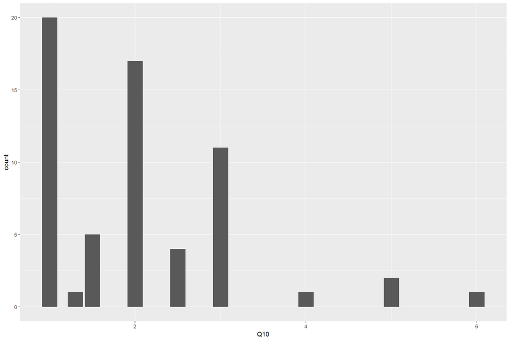

```r
survey$Q10<-as.numeric(survey$Q10)
ggplot(survey, aes(x = Q10)) +
  geom_histogram(stat = "count")
```

The majority of students only drink between 1 and 2 litres of water.

# Q11:

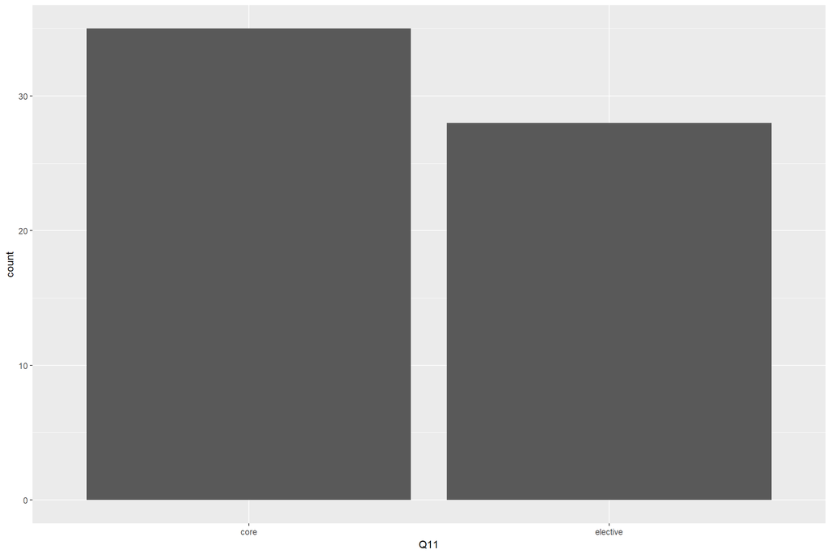

```r
survey$Q11[survey$Q11=="A"] <- "elective"
survey$Q11[survey$Q11=="B"] <- "core"
ggplot(data = survey, aes(x = Q11)) +
  geom_bar()
```

The majority of students are taking this unit as a core, however the difference is not too large.

# Q12:

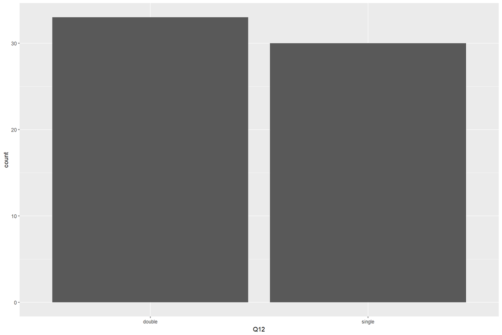

```r
survey$Q12[survey$Q12=="A"] <- "single"
survey$Q12[survey$Q12=="B"] <- "double"
ggplot(data = survey, aes(x = Q12)) +
  geom_bar()
```

The majority of students take a double degree, however the difference between these two are also not too large.

# Q13:

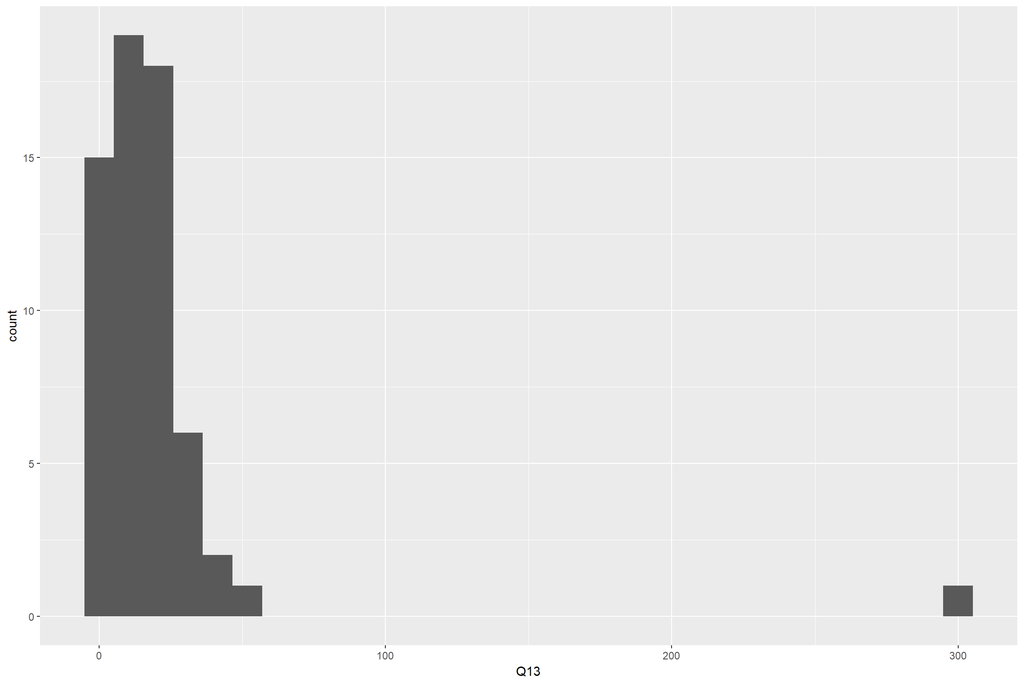

```r
#remove dollars
survey <- survey %>%
  mutate(Q13 = sub("dollars", "", Q13))
survey$Q13[survey$Q13=="$30"] <- "30"
survey$Q13[survey$Q13=="$15"] <- "15"
survey$Q13[survey$Q13=="$35"] <- "35"

survey$Q13<-as.numeric(survey$Q13)
ggplot(data=survey, aes(x=Q13)) +
  geom_histogram()
```

```r
#survey$Q13a<-as.numeric(gsub("*\\D+\\.\\D*", "", survey$Q13))
#survey$Q13a<-as.numeric(gsub("\\D", "", survey$Q13))
```

Most students use below 50 dollars per week on food each day, however someone uses 300 dollars on average per day at uni.

# Q14:

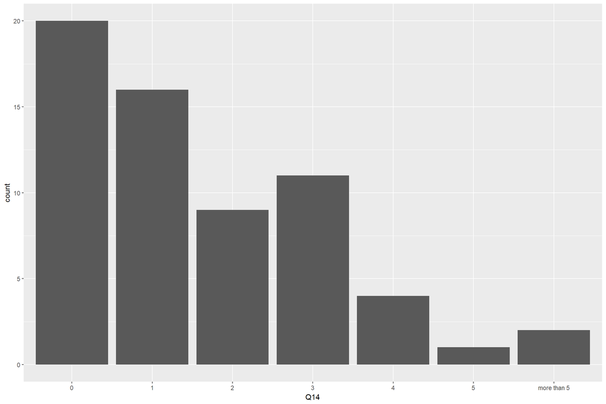

```r
#we change the responses to the actual number
survey$Q14[survey$Q14=="A"] <- "0"
survey$Q14[survey$Q14=="B"] <- "1"
survey$Q14[survey$Q14=="C"] <- "2"
survey$Q14[survey$Q14=="D"] <- "3"
survey$Q14[survey$Q14=="E"] <- "4"
survey$Q14[survey$Q14=="F"] <- "5"
survey$Q14[survey$Q14=="G"] <- "more than 5"
ggplot(data = survey, aes(x=Q14)) +
  geom_bar()
```

The majority of students do know at least one “Sam” as a friend, however there are also a lot of students who do not know a single “Sam” as a friend.

# Q15.

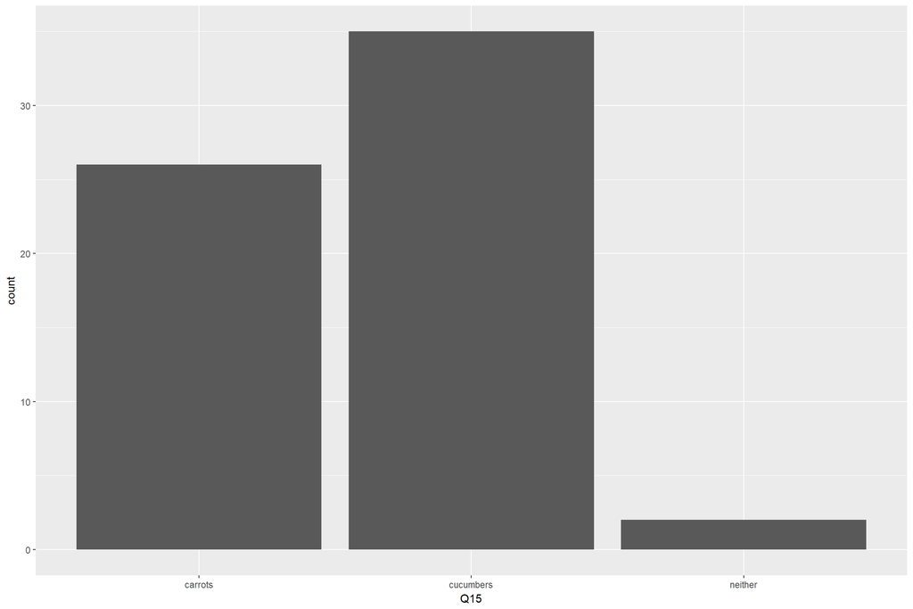

```r
#we change the responses to cucumbers/carrots/neither
survey$Q15[survey$Q15=="A"] <- "cucumbers"
survey$Q15[survey$Q15=="B"] <- "carrots"
survey$Q15[survey$Q15=="C"] <- "neither"
ggplot(data = survey, aes(x=Q15)) +
  geom_bar()
```

The majority of students prefer cucumbers.

# Q16:

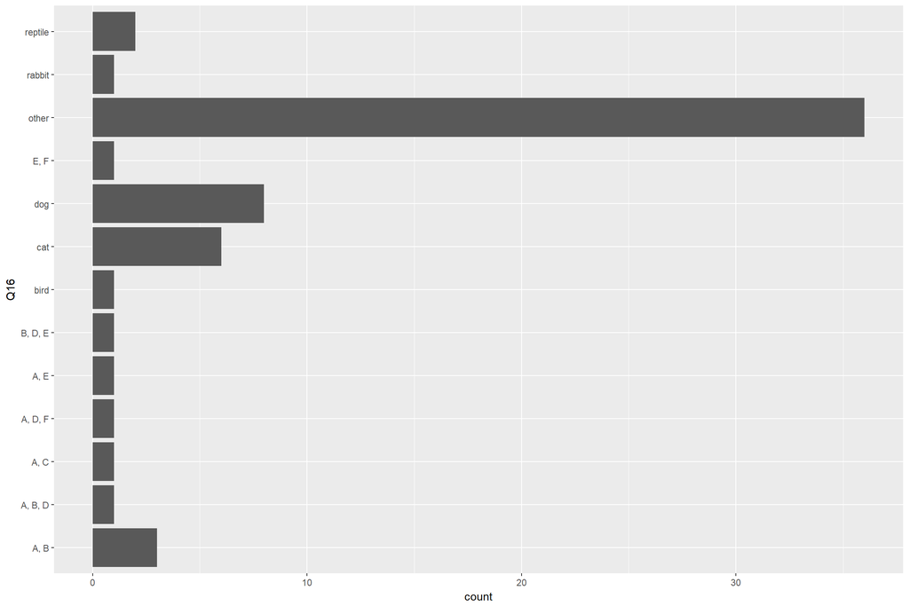

```r
#we change the answers to the animals
survey$Q16[survey$Q16=="A"] <- "dog"
survey$Q16[survey$Q16=="B"] <- "cat"
survey$Q16[survey$Q16=="C"] <- "rabbit"
survey$Q16[survey$Q16=="D"] <- "bird"
survey$Q16[survey$Q16=="E"] <- "reptile"
survey$Q16[survey$Q16=="F"] <- "other"
ggplot(data = survey, aes(x=Q16)) +
  geom_bar() + coord_flip()
```

THe majority of students own “other”" animals. We would assume this is so large since it includes students who own no pets.

# Q17:

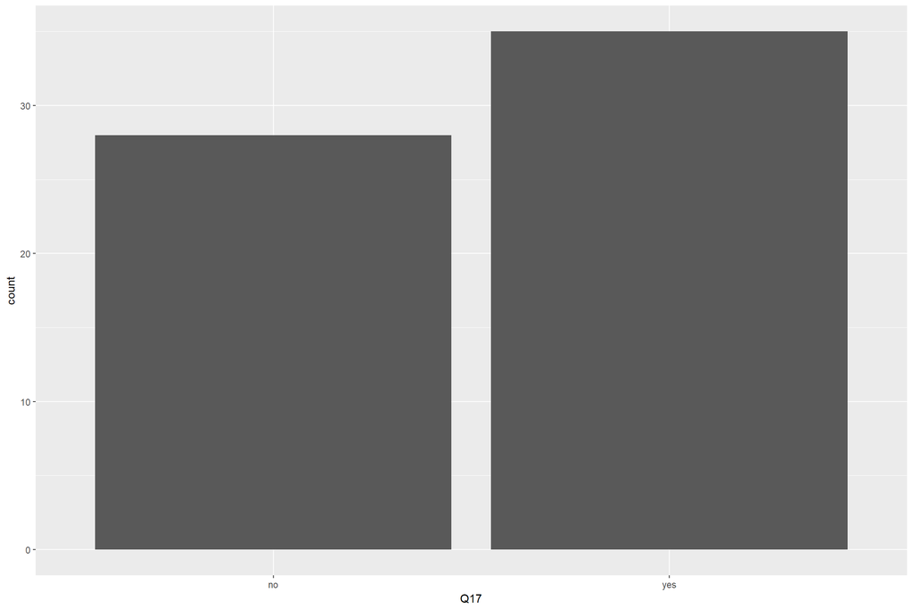

```r
#we change the answers to yes/no
survey$Q17[survey$Q17=="A"] <- "yes"
survey$Q17[survey$Q17=="B"] <- "no"
ggplot(data = survey, aes(x=Q17)) +
  geom_bar()
```

The majority of students do have coding experience, however the different between students who do and do not have coding experience is also quite small.

# Q18:

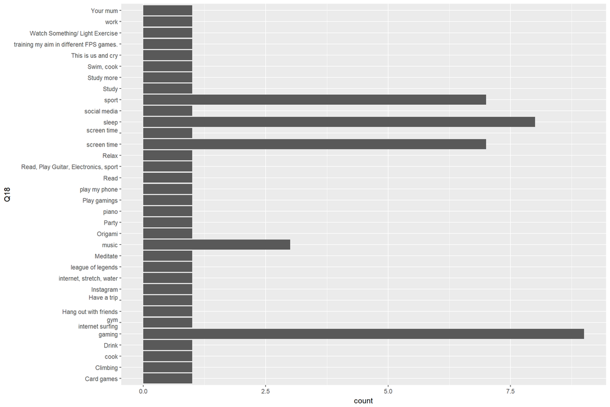

```r
survey <- survey %>%
  #music related response to "music"
  mutate(Q18 = sub("listen to music", "music", Q18)) %>%
  mutate(Q18 = sub("To listen music", "music", Q18)) %>%
  mutate(Q18 = sub("listen music", "music", Q18)) %>%
  # tv and video related responses to "screen time"
  mutate(Q18 = sub("TV", "screen time", Q18)) %>%
  mutate(Q18 = sub("watch vedio", "screen time", Q18)) %>%
  mutate(Q18 = sub("watch youtube", "screen time", Q18)) %>%
  mutate(Q18 = sub("youtube", "screen time", Q18)) %>%
  mutate(Q18 = sub("watch tv", "screen time", Q18)) %>%
  mutate(Q18 = sub("the office", "screen time", Q18)) %>%
  mutate(Q18 = sub("tv", "screen time", Q18)) %>%
  #gaming related responses to "gaming"
  mutate(Q18 = sub("Play games", "gaming", Q18)) %>%
  mutate(Q18 = sub("video game", "gaming", Q18)) %>%
  mutate(Q18 = sub("Games", "gaming", Q18)) %>%
  mutate(Q18 = sub("computer games", "gaming", Q18)) %>%
  mutate(Q18 = sub("play games", "gaming", Q18)) %>%
  mutate(Q18 = sub("Game", "gaming", Q18)) %>%
  mutate(Q18 = sub("Play video games", "gaming", Q18)) %>%
  #sport related answers to "sport"
  mutate(Q18 = sub("Basketball", "sport", Q18)) %>%
  mutate(Q18 = sub("Gym", "sport", Q18)) %>%
  mutate(Q18 = sub("Sport", "sport", Q18)) %>%
  #sleep to "sleep"
  mutate(Q18 = sub("Sleep", "sleep", Q18))
ggplot(data = survey, aes(x=Q18)) +
  geom_bar() + coord_flip()
```

The top 3 ways students do to take a break from study are gaming, sleeping and screen time.

# Q19:

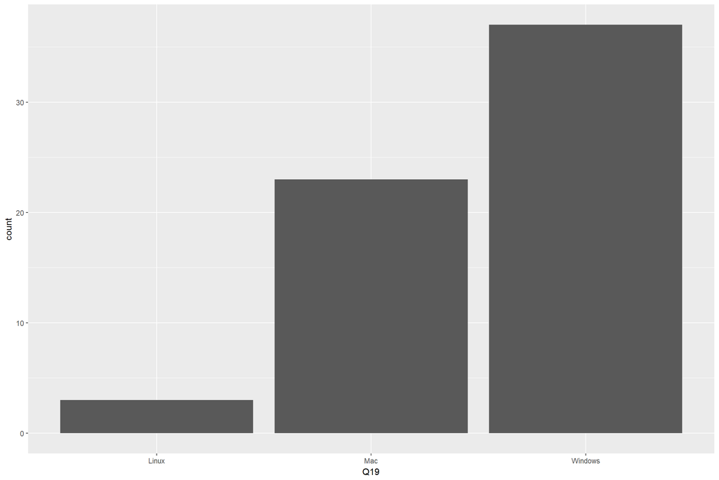

```r
#change responses to names
survey$Q19[survey$Q19=="A"] <- "Windows"
survey$Q19[survey$Q19=="B"] <- "Mac"
survey$Q19[survey$Q19=="C"] <- "Linux"
survey$Q19[survey$Q19=="D"] <- "Other"
ggplot(data = survey, aes(x=Q19)) +
  geom_bar()
```

THe majority of students have Windows computers.

# Q20:

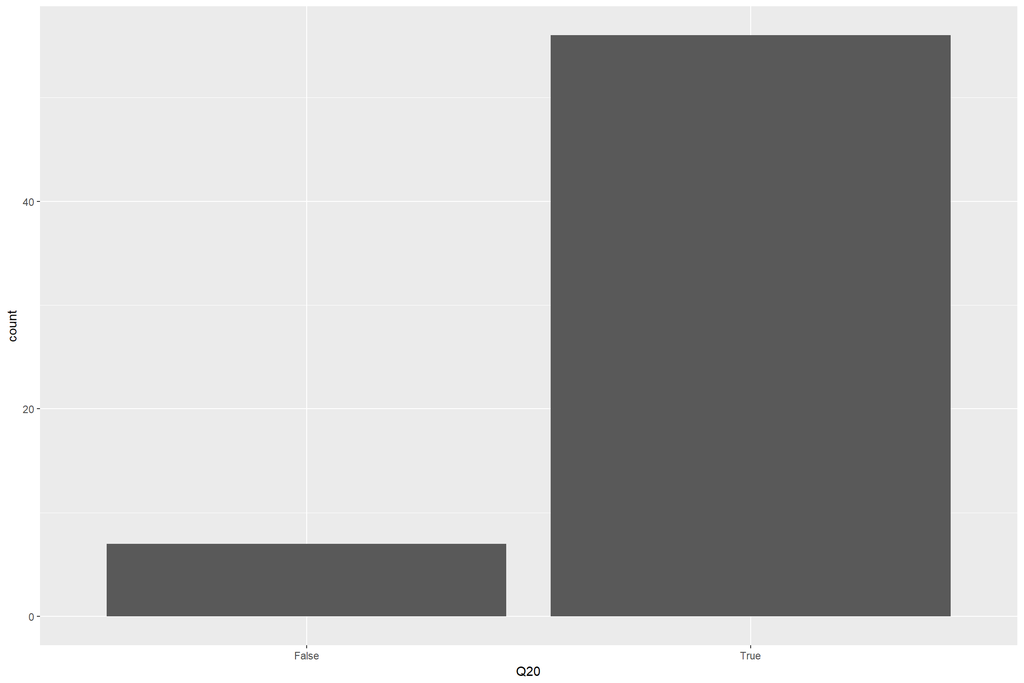

```r
ggplot(data = survey, aes(x=Q20)) +
  geom_bar()
```

The majority of students support same-sex marriage.

# cleaning up Q21

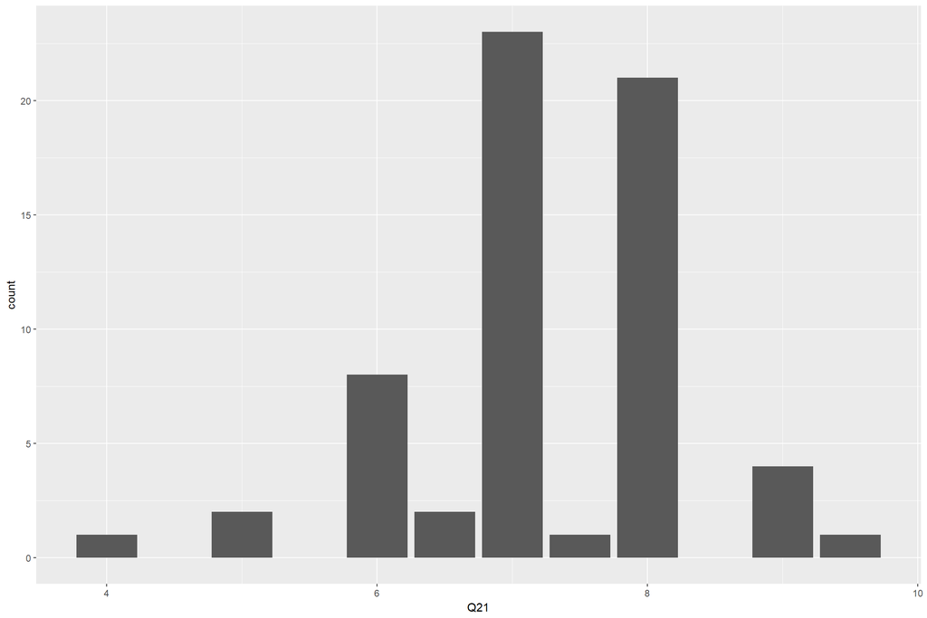

```r
library(tidyverse)
library(stringr)

survey <- survey %>%
  # change "6\n" to "6"
  mutate(Q21 = sub("6\n", "6", Q21)) %>%
  # change "7;30" to "7.5"
  mutate(Q21 = sub("7;30", "7.5", Q21))
#changing the 27th responses to 7
survey$Q21[27] <- "7.0"
#changing all responses to numbers
survey <- survey %>% mutate(Q21 = as.numeric(Q21))

ggplot(survey, aes(x= Q21)) +
  geom_bar()
```

The majority of students get between 6 and 8 hours of sleep per day.

# Q22

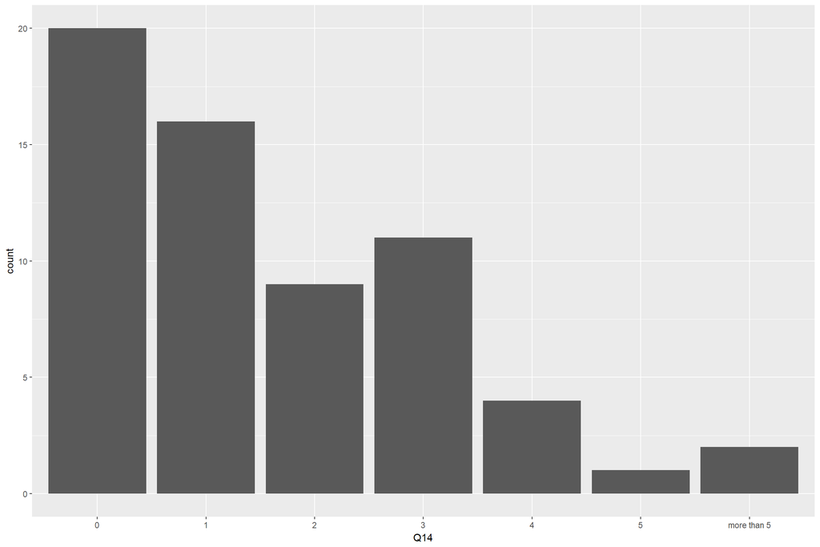

```r
#remove days
survey <- survey %>%
  mutate(Q22 = sub("days", "", Q22))
#changing the responses to all numbers
survey <- survey %>% mutate(Q22 = as.numeric(Q22))
ggplot(survey, aes(x=Q14)) +
  geom_bar()
```

# Q23

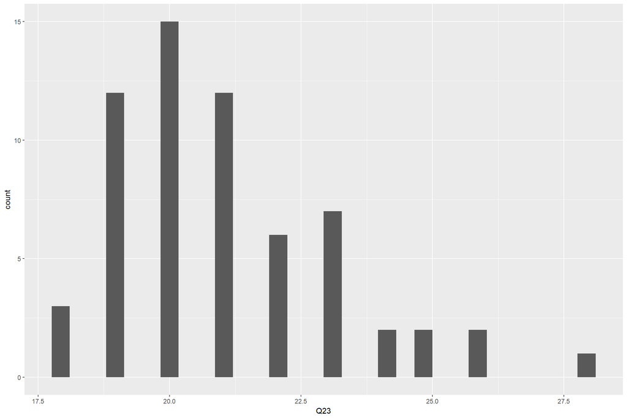

```r
survey <- survey %>%
  #changing the year of birth to their age
  mutate(Q23 = sub("1997", "21", Q23))
#this idiot needs to be deleted
survey$Q23[63] <- NA
survey <- survey %>% mutate(Q23 = as.numeric(Q23))
ggplot(survey, aes(x=Q23)) +
  geom_histogram()
```

The majority of students range from 19-21.

# Q24

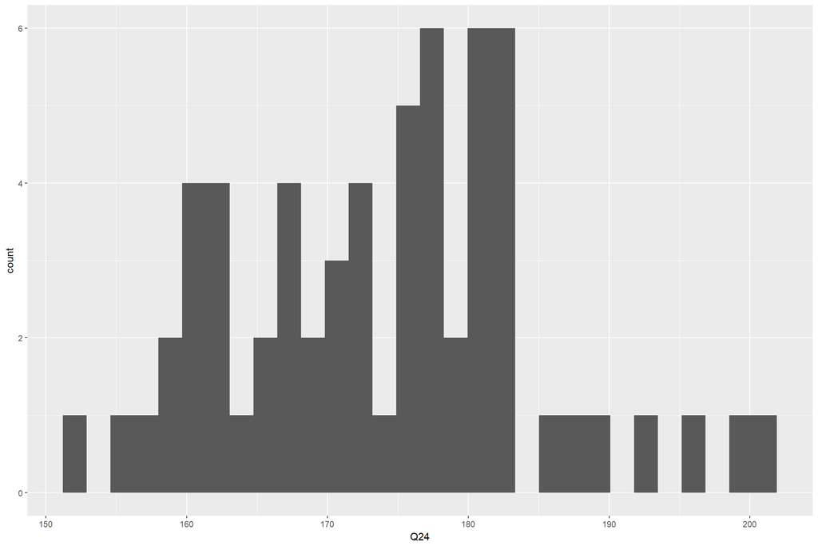

```r
#changing the "I don't know" to NA
survey$Q24[38] <- NA
survey <- survey %>% mutate(Q24 = as.numeric(Q24))
ggplot(survey, aes(x=Q24)) +
  geom_histogram()
```

The majority of students range from 160cm to 180cm.

# Q25

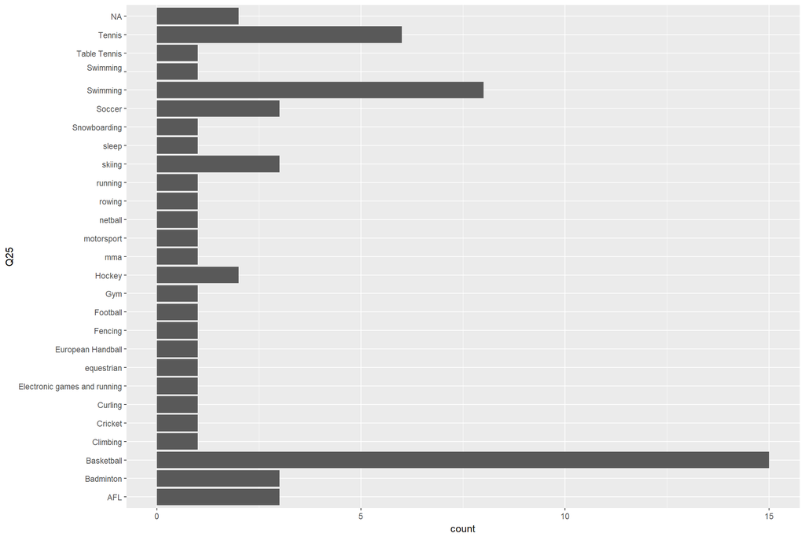

```r
survey <- survey%>%
  #we are simply changing all the responses so they are the same
  mutate(Q25 = sub("basketball", "Basketball", Q25))%>%
  mutate(Q25 = sub("swimming", "Swimming", Q25))%>%
  mutate(Q25 = sub("swim", "Swimming", Q25))%>%
  mutate(Q25 = sub("tennis", "Tennis", Q25))%>%
  mutate(Q25 = sub("badminton", "Badminton", Q25))%>%
  mutate(Q25 = sub("afl", "AFL", Q25))%>%
  mutate(Q25 = sub("football", "Football", Q25)) %>%
  mutate(Q25 = sub("soccer", "Soccer", Q25))
#Changing no answer responses to NA
survey$Q25[32] <- NA
survey$Q25[40] <- NA
ggplot(survey, aes(x=Q25)) +
  geom_bar() + coord_flip()
```

The most popular sport is basketball, followed by swimming, then tennis.

# Q26

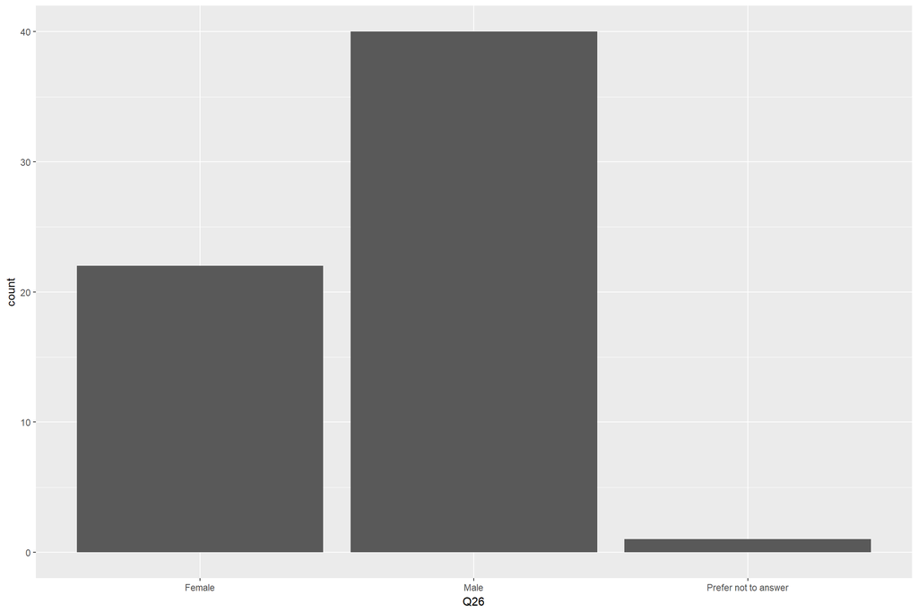

```r
#changing the responses to their genders
survey$Q26[survey$Q26=="A"] <- "Female"
survey$Q26[survey$Q26=="B"] <- "Male"
survey$Q26[survey$Q26=="C"] <- "Prefer not to answer"

ggplot(survey, aes(x= Q26)) +
  geom_bar()
```

The majority of students in this unit are male.

# Q27

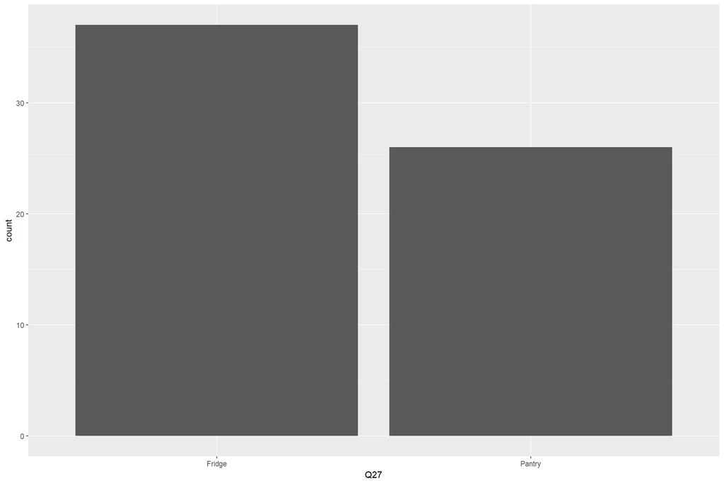

```r
#changing the responses to their names
survey$Q27[survey$Q27=="A"] <- "Fridge"
survey$Q27[survey$Q27=="B"] <- "Pantry"

ggplot(survey, aes(x= Q27)) +
  geom_bar()
```

The majority of students keep their tomato sauce in the fridge.

# Q28

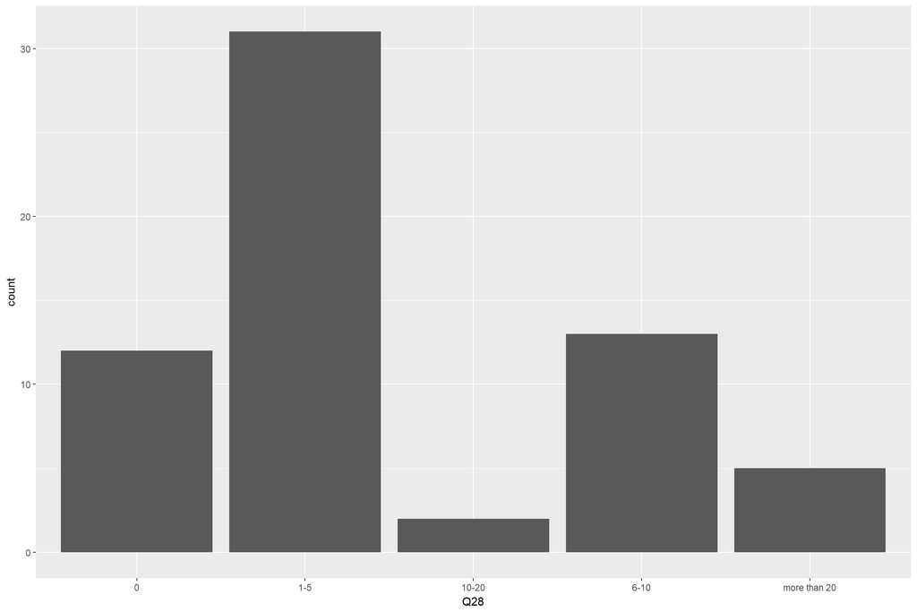

```r
#changing the responses to their ranges
survey$Q28[survey$Q28 == "A"] <- "0"
survey$Q28[survey$Q28 == "B"] <- "1-5"
survey$Q28[survey$Q28 == "C"] <- "6-10"
survey$Q28[survey$Q28 == "D"] <- "10-20"
survey$Q28[survey$Q28 == "E"] <- "more than 20"

ggplot(survey, aes(x= Q28)) +
  geom_bar()
```

The majority os students read 1-5 books last year.

# Q29

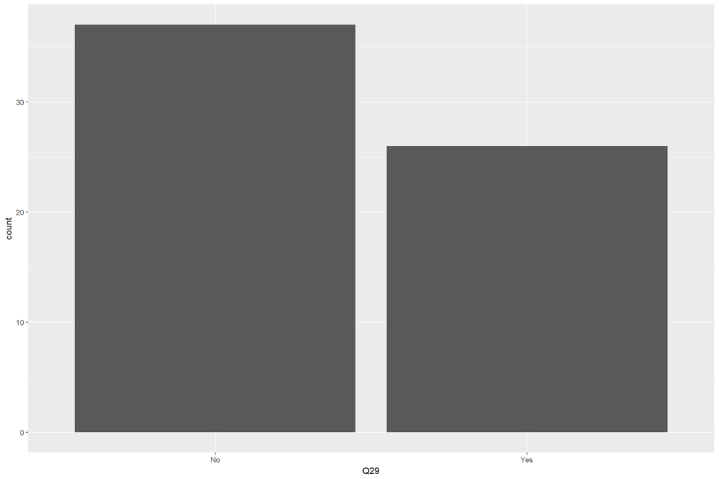

```r
#changing the responses to yes/no
survey$Q29[survey$Q29 == "A"] <- "Yes"
survey$Q29[survey$Q29 == "B"] <- "No"

ggplot(survey, aes(x= Q29)) +
  geom_bar()
```

The majority os students have not been to the Australian Open.

# Q30

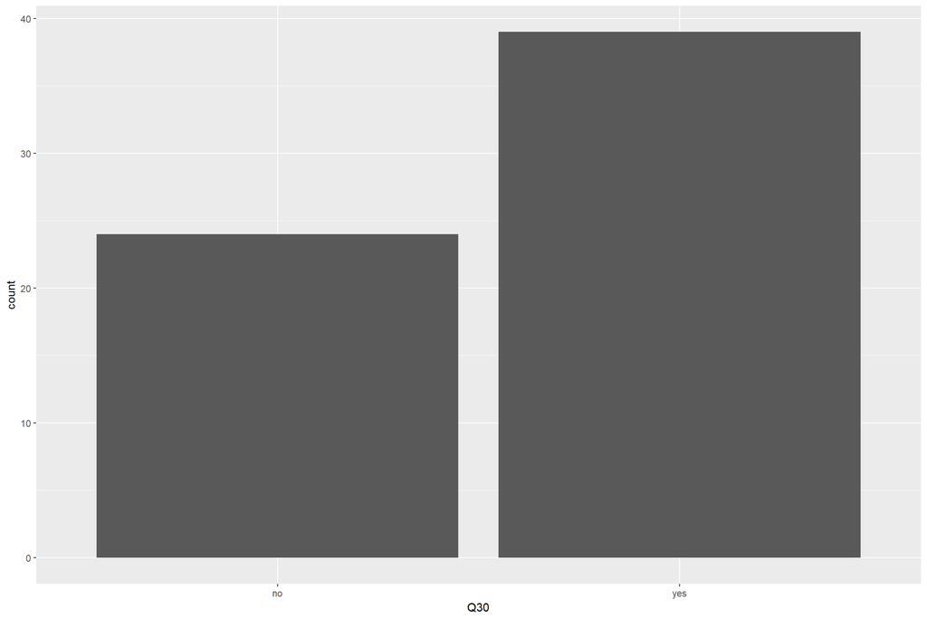

```r
#changing the responses to yes/no
survey$Q30[survey$Q30 == "A"] <- "no"
survey$Q30[survey$Q30 == "B"] <- "yes"

ggplot(survey, aes(x= Q30)) +
  geom_bar()
```

The majority of students are struggling with this unit.

# Q31

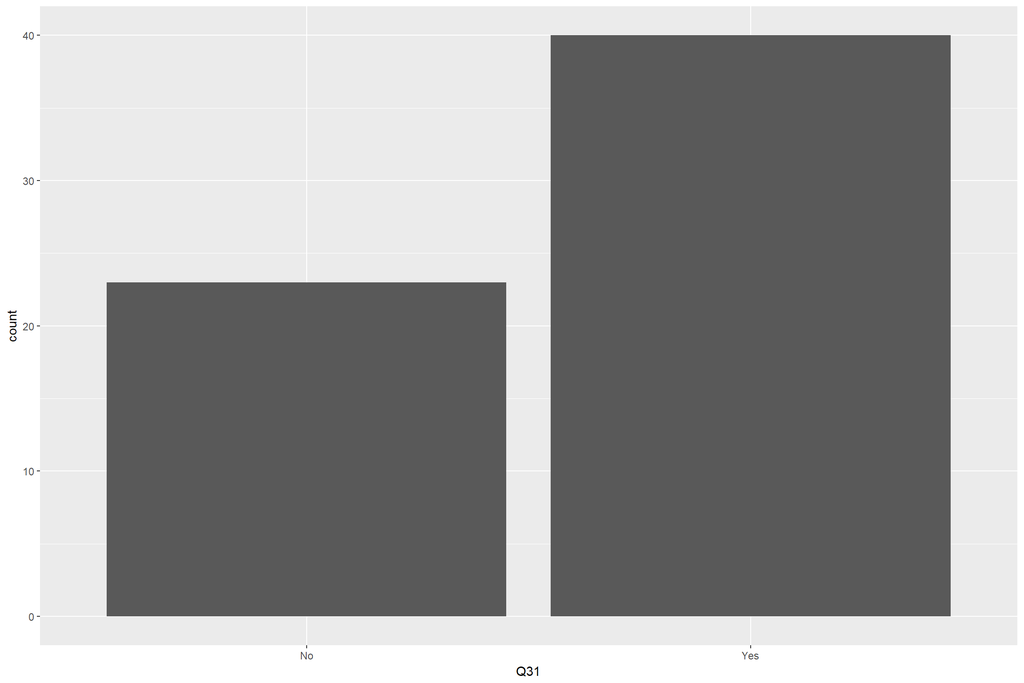

```r
#changing responses to yes/no
survey$Q31[survey$Q31 == "A"] <- "Yes"
survey$Q31[survey$Q31 == "B"] <- "No"

ggplot(survey, aes(x= Q31)) +
  geom_bar()
```

THe majority of students do enjoy this unit.

# Q32

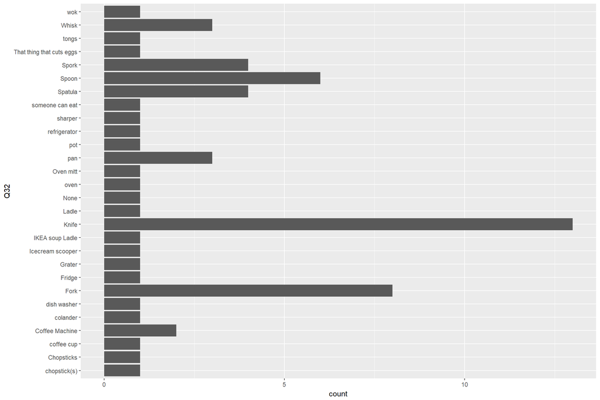

```r
survey <- survey %>%
  #knife to "Knife"
  mutate(Q32 = sub("knife", "Knife", Q32))%>%
  #spoon related response to "Spoon"
  mutate(Q32 = sub("Soup Spoon", "Spoon", Q32))%>%
  mutate(Q32 = sub("spoon", "Spoon", Q32))%>%
  mutate(Q32 = sub("Soup Spoon", "Spoon", Q32))%>%
  mutate(Q32 = sub("a Spoon", "Spoon", Q32))%>%
  #fork to "Fork"
  mutate(Q32 = sub("fork", "Fork", Q32))%>%
  #ladle related answers to "Ladle"
  mutate(Q32 = sub("ladle", "Ladle", Q32))%>%
  mutate(Q32 = sub("IKEA soup ladle", "Ladle", Q32))%>%
  mutate(Q32 = sub("spork", "Spork", Q32))%>%
  mutate(Q32 = sub("whisk", "Whisk", Q32))%>%
  mutate(Q32 = sub("spatula", "Spatula", Q32))%>%
  mutate(Q32 = sub("Coffee machine", "Coffee Machine", Q32))%>%
  mutate(Q32 = sub("chopstick(s)", "Chopsticks", Q32))


ggplot(survey, aes(x=Q32)) +
  geom_bar() + coord_flip()
```

The top 3 kitchen utensils that students consider themselves to be are knives, forks then spoons.

# Q33

[figure not shown]

```r
#changing responses to yes/no
survey$Q33[survey$Q33 == "A"] <- "Yes"
survey$Q33[survey$Q33 == "B"] <- "No"

ggplot(survey, aes(x= Q33)) +
  geom_bar()
```

The majority of students like cheese.

# comparing the number of the year level to that of double vs single degrees

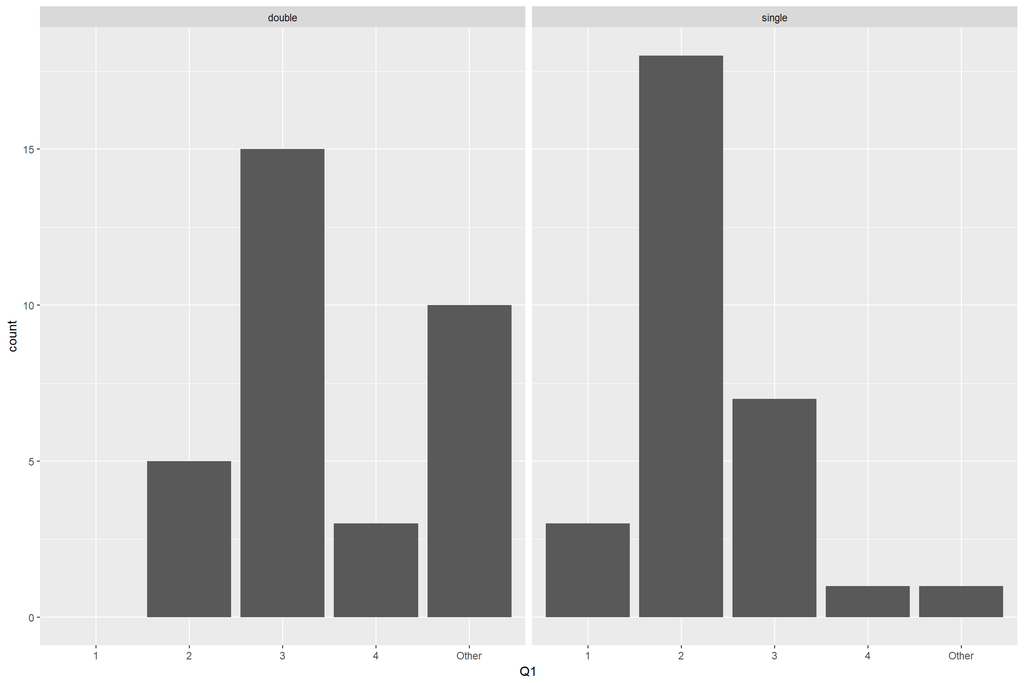

```r
ggplot(survey) +
  geom_bar(aes(x=Q1)) +
  facet_wrap(~Q12)
```

We can see that in ETC1010 majority of the students are in there second year doing a single degree. However there is also a high number of double degree students in their third year also completeing this unit

# compare the number of study hours put in according to the level of year each student is in

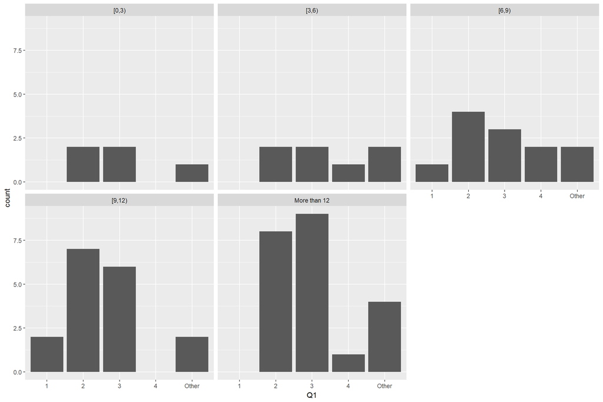

```r
ggplot(survey)+
  geom_bar(aes(x=Q1)) +
  facet_wrap(~Q8)
```

# Comparing “Are you strggling with this unit” (Q30) and “Do you like ETC1010” (Q31)

```r
library(gmodels)
CrossTable(survey$Q30, survey$Q31,prop.chisq=FALSE)


   Cell Contents
|-------------------------|
|                       N |
|           N / Row Total |
|           N / Col Total |
|         N / Table Total |
|-------------------------|


Total Observations in Table:  63


             | survey$Q31
  survey$Q30 |        No |       Yes | Row Total |
-------------|-----------|-----------|-----------|
          no |         4 |        20 |        24 |
             |     0.167 |     0.833 |     0.381 |
             |     0.174 |     0.500 |           |
             |     0.063 |     0.317 |           |
-------------|-----------|-----------|-----------|
         yes |        19 |        20 |        39 |
             |     0.487 |     0.513 |     0.619 |
             |     0.826 |     0.500 |           |
             |     0.302 |     0.317 |           |
-------------|-----------|-----------|-----------|
Column Total |        23 |        40 |        63 |
             |     0.365 |     0.635 |           |
-------------|-----------|-----------|-----------|
```

# Comparing “Are you strggling with this unit” (Q30) and “Do you have prior coding experience?” (Q17)

```r
CrossTable(survey$Q30, survey$Q17,prop.chisq=FALSE)


   Cell Contents
|-------------------------|
|                       N |
|           N / Row Total |
|           N / Col Total |
|         N / Table Total |
|-------------------------|


Total Observations in Table:  63


             | survey$Q17
  survey$Q30 |        no |       yes | Row Total |
-------------|-----------|-----------|-----------|
          no |         1 |        23 |        24 |
             |     0.042 |     0.958 |     0.381 |
             |     0.036 |     0.657 |           |
             |     0.016 |     0.365 |           |
-------------|-----------|-----------|-----------|
         yes |        27 |        12 |        39 |
             |     0.692 |     0.308 |     0.619 |
             |     0.964 |     0.343 |           |
             |     0.429 |     0.190 |           |
-------------|-----------|-----------|-----------|
Column Total |        28 |        35 |        63 |
             |     0.444 |     0.556 |           |
-------------|-----------|-----------|-----------|
```

Just over 55% of the people in the unit have prior coding experience, and two thirds of these people are not struggling. The vast majority of people (96%) of people with no coding experience are struggling in the unit.

```r
write_csv(survey, path="data/survey_tidy.csv")
```